# No Replication Without Process Documentation: An Assessment of Management Strategy Evaluations

Jonathan W. Cummings, Amanda Hart, Gavin Fay

School for Marine Science and Technology, University of Massachusetts - Dartmouth

Abstract

The aim and vision for fisheries management that comes from management strategy evaluation and adaptive management is a nobel and aspirational vision. We review MSE documentation in the published literature to appraise the achievement of this vision, finding that reality doesn’t fully reflect this vision. The steps taken to complete the MSE process often are not documented. Scientists often fulled the role of fishery stakeholders, seemingly selecting the objectives and alternatives to evaluate in most MSEs. Facilitators and decision analysts – participants focused on the decision making process – were rarely participants in MSE processes. Conservation, Economic, and Yield focused objectives were commonly considered in MSE processes, while broader social objectives were rarely considered. The picture painted by MSE documentation is primarily one of scientist driven simulation studies rather than management driven decision processes, with limited process documentation.

# Introduction

The calls for fisheries management to utilize management strategy evaluation and adaptive management are both aspirational and noble in their aim and vision. Management strategy evaluation (MSE) is “widely considered to be the most appropriate way to evaluate the trade‐offs achieved by alternative management strategies and to assess the consequences of uncertainty for achieving management goals” (Punt et al. 2014). The positive aspects of MSE that have been listed include that it is “A tool that scientists and managers can use to simulate the workings of a fisheries system and allow them to test whether potential harvest strategies—or management procedures— can achieve pre-agreed management objectives.”(Nickson 2016), that it “can be used to identify a ‘best’ management strategy among a set of candidate strategies” (Punt 2014) and “MSE has the advantage of being able to reveal the trade-offs among a range of possible management decisions, and should assist our Commissioners in determining whether the objectives should be weighted differently. Specifically, to provide the information on which to base a rational decision, given objectives, preferences, and attitudes to risk.” – International Pacific Halibut Commission Based on these descriptions MSE is a compelling tool to support and improve fisheries management decisions.

In terms of the MSE process, it is described as being “at the interface between science and policy.” (Punt 2014) and being an “Undertaking [that] requires scientists, managers, and stakeholders to be involved throughout the process.” (“Management Strategy Evaluation” 2017) The Internation Pacific Halibut Commission (2017) also states, “While the scientists do the modelling, managers must offer extensive input. Because of the many steps and the iterative process, communication among parties is critical for achieving buy-in on the results of the management strategy evaluation.”

Adaptive management developed in fisheries management as a means to improve the achievement of objectives through time, when learning can aid achieving those objectives. For example, the Millennium Ecosystem Assessment (2005) defines adaptive management as “A systematic process for continually improving management policies and practices by learning from the outcomes of previously employed policies and practices. In active adaptive management, management is treated as a deliberate experiment for purposes of learning.” We contend that scientific publication is essentially a process intended to support adaptive management, in that researchers gain knowledge from the decisions made and outcomes produced by previous work to inform their decisions.

### Objectives

Our overall objectives is to understanding of how MSEs utilize standard components of decision making processes and to what extent their documentation can support learning within the MSE practitioner community? Given that scientific publication is the primary means of communicating the results of MSE, we review the scientific literature to assess the extent to which the process and aims of MSE, and adaptive management are being achieved and supported by the scientific literature. We use the structured decision making (SDM) process (USGS 2019) – the decision making framework in which adaptive management occurs – as our framework for evaluation. Using this framework we review published MSEs to:

- Determine what questions MSE processes are adressing
- Identify the objectives and alternatives considered in MSE
- Determine the prevalence of explicit documentation and use of decision making steps in the MSE process, and
- Identify participants in MSE processes.

We also conduct a focused analysis of MSE processes that address the influence of climate change on fisheries management, highlighting unique aspects of MSE processes that model climate change as a driver of system status.

# Methods

## Finding and Sampling the MSE Literature

We conducted our search for MSEs in the SCI-EXPANDED index from Web of Science, searching for “management strategy evaluation” by topic across all years on January 8th, 2019. This search returned 253 results. We reviewed a random sample of 30 articles that document a MSE, removing articles that were reviews, meta-analyses, or simply cited other MSE articles from our sample. Of the 253 articles, 11 included climate change as a driver of fishery status, and after removing other articles we estimate 110-160 articles document a MSE.

| MSE type | Count |
| --- | --- |
| Published (estimated*) | ~142 |
| Random Sample | 30 |
| Climate Change | 11 |

## Reviewing MSE documentation

In the consequence group we report the drivers included as the primary factors influencing the predictions produced by the MSE model and report how the consequence predictions were made. The information reported here addresses what question the MSE was designed to address, and how it was addressed.

In the objectives group we report the category of objectives considered in the MSE, and what type of objectives were considered. We noted four types of objectives: strategic objectives regarding the overall mission of the system in which the decision evaluated by the MSE falls, process objectives addressing how the management decision addressed by the MSE would be made, fundamental objectives addressing the goals of the management decision, and means objectives addressing means to acheiving fundamental objectives of the management decision.

In the stages group we report whether the stages (Problem, Objectives, Alternatives, Consequences, Trade-offs, and Decision) of the structured decision making framework were explicitly completed and documented. We also report whether the MSE results were adopted in subsequent management. In many cases the process used to elicit objectives and alternatives was not explicit, but some information is provided or can be gleaned about who participated in the production of those components of the MSE. In those cases we record and report who those participants were, refering to them as subjective participants in the objectives or alternatives process.

In the process group we report who lead the MSE, who participated in it, if the roles of participants were established and documented.

We collected additional information about the MSEs we reviewed. For a full description of the information recorded in database columns for this MSE review see the supplemental information (supplement), and for the full results see our shinyapp (https://jonathancummings.shinyapps.io/MSEreview/).

# Results

### What questions and management objectives do MSEs address?

We found that uncertainty was the main driver of the system state included in management strategy evaluations, with uncertainty included in 21 of the 30 evaluations we reviewed (Table 1). In addition to uncertainty about the system model itself, monitoring methodology was the most prevalent driver in MSE models, but a variety of drivers were considered across the random sample of MSEs.

Table 1: Drivers included in management strategy evaluations

| Driver | Percent | Frequency |
| --- | --- | --- |
| Uncertainty | 70 | 21 |
| Monitoring Methodology | 20 | 6 |
| Spatial Structure | 13 | 4 |
| Allowable Catch Adjustment | 10 | 3 |
| Environmental Conditions | 10 | 3 |
| Fishing Behavior | 10 | 3 |
| Implementation Uncertainty | 10 | 3 |
| Ecosystem Based Management | 7 | 2 |
| Species Interactions | 7 | 2 |
| Climate Change | 3 | 1 |
| Landing Regulations | 3 | 1 |
| Management Timeline | 3 | 1 |
| Migration | 3 | 1 |
| Multiple Sectors in Fishery | 3 | 1 |
| Stock Status | 3 | 1 |

Conservation objectives were present in nearly all of the MSEs we reviewed (Table 2). Yield and economic objectives were present in about three quarters of the MSEs, while social objectives were only included in 2 of the MSEs.

Table 2: Consideration of objective categories in management strategy evaluation

| Objective Category | Percent | Frequency |
| --- | --- | --- |
| Conservation | 93 | 28 |
| Economic | 73 | 22 |
| Yield | 73 | 22 |
| Social | 7 | 2 |
| Utility | 3 | 1 |

## Are structured decision making steps explicit in MSEs?

The majority of MSEs did not explicitly document how the stages of the MSE process – defined using the SDM framework – were completed (Table 3). The most documented stage was the alternative stage with 6 MSEs documenting this stage of the process. Three of the 30 MSEs explicitly documented a tradeoff analysis and 2 of the 30 documented a management decision. One of the 30 documented either the roles of participants in the MSE process or that the results of the MSE were adopted.

Table 3: Prevalence of explicit documentation of stages in the MSE process

| Explicit | Number | Percent |
| --- | --- | --- |
| Process | 5 | 17 |
| Problem | 5 | 17 |
| Objectives | 5 | 17 |
| Alternatives | 6 | 20 |
| Tradeoffs | 3 | 10 |
| Decision | 2 | 7 |
| Results Adopted | 1 | 3 |

### Who is involved in MSEs?

MSEs were rarely explicit about the roles participants played in MSE processes, as only one MSE documented participant roles (Table 4). None of the MSEs noted whether or not public meetings were held in which the public could participate in the MSE process.

Table 4: Prevalence of explicit roles for MSE participants and meetings that were open to the public during the MSE process

| Explicit | Number | Percent |
| --- | --- | --- |
| Roles | 1 | 3 |
| Open Meetings | 0 | 0 |

The primary participants and leaders of the MSE processes were scientists, with some lead by governments and management agencies (Figure 1). Scientist lead 73 percent of the MSE processes, with another 23 percent lacking documentation that made the leader of the process clear.

Scientists were participants in nearly all of the reviewed MSE processes. Other stakeholders in MSE processes were less frequent participants. Members of the fishery participated in 30 percent, management and government representatives in 23 percent, representatives of independent institutions in 7 percent, and the members of the public in 3 percent of reviewed MSEs. Decision makers, those responsible for selecting the management plan to implement, were participants in 13 percent of MSEs. Experts, a possible source of data or predictions, participated in 3 percent of the MSEs reviewed. Participants involved to the assist the MSE process itself, facilitators and analysts participated in 10 and 3 percent of MSE processes respectively.

Objectives and alternatives were elicited from a variety of participants. About 10 percent of the objectives and alternatives explicitly were produced by stakeholders in the fisheries, coming from management, government, or the fishery. In most cases the source of the objectives and alternatives was not explicit. In those cases scientists selected these components most frequently.

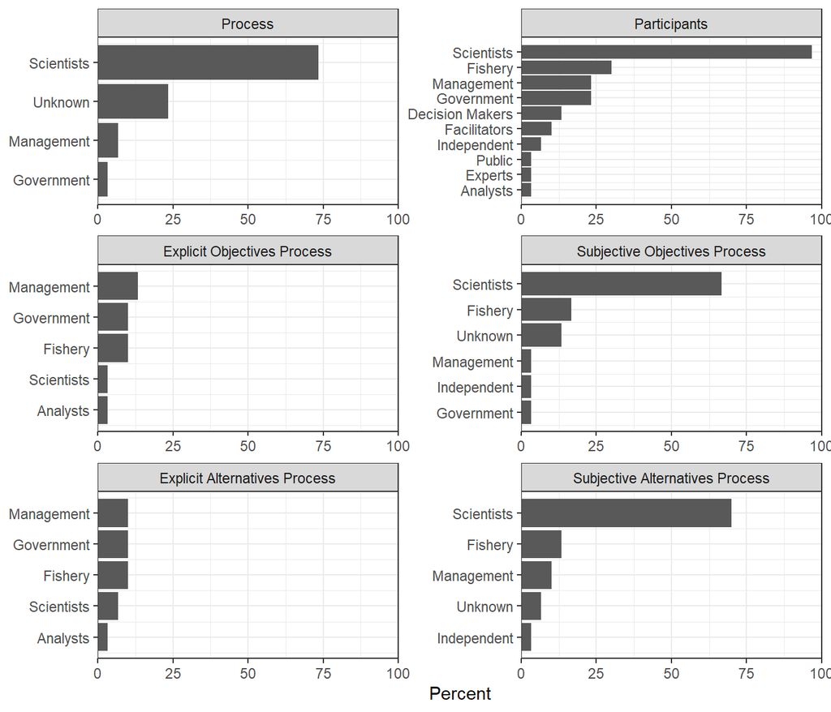

Figure 1: Who guided, participated in, or provided input during the specified steps of the MSE process

# Climate Change in MSE (As *Box Insert*)

Fisheries management has mostly focused on fishing impacts with ecosystem status viewed as a background constant. The increasing rate of climate change is changing this dynamic, bringing ecosystem status to the forefront of fisheries management.

We review published MSEs including climate change as a driver against the steps of the SDM framework to: Highlight unique aspects of MSEs that model climate change as a driver to inform fisheries management in a changing climate.

We found that as of the end of December 2018 11 MSEs included climate change as a driver. These MSEs have been concentrated in North America and Australia (Figure 2).

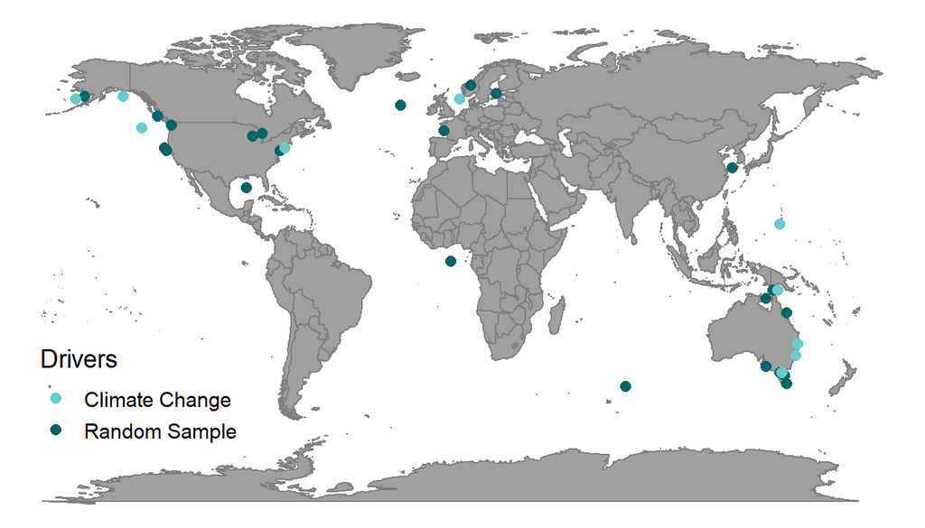

Figure 2: Map of MSE study locations.

Table 5: Drivers included in climate change management strategy evaluations

| Driver | Percent | Frequency |
| --- | --- | --- |
| Climate Change | 100 | 11 |
| Uncertainty | 18 | 2 |
| Environmental Conditions | 9 | 1 |
| Habitat Change | 9 | 1 |
| Migration | 9 | 1 |
| Monitoring Methodology | 9 | 1 |
| Spatial Structure | 9 | 1 |

More objectives were considered per MSE in the random sample of MSEs than in the climate change MSEs (Table 6). Climate change MSEs were less likely to consider economic and social objectives than the random sample (Table 7).

Table 6: Number of objectives considered per management strategy evaluation

| Analysis | Per MSE |
| --- | --- |
| Random Sample | 6.0 |
| Climate Change | 4.1 |

Table 7: Objective categories considered in management strategy evaluations

| Analysis | Objective Category | Percent | Frequency |
| --- | --- | --- | --- |
| Random Sample | Conservation | 93 | 28 |
| Climate Change | Conservation | 91 | 10 |
| Random Sample | Economic | 73 | 22 |
| Climate Change | Economic | 55 | 6 |
| Random Sample | Social | 7 | 2 |
| Random Sample | Utility | 3 | 1 |
| Random Sample | Yield | 73 | 22 |
| Climate Change | Yield | 82 | 9 |

Climate change MSEs were more likely to explicitly document the alternative elicitation and trade-off analysis steps, but otherwise were less likely to document steps in the decision process.

Table 8: Prevalence of explicit documentation of stages in climate change MSE processes

| Explicit | Number | Percent |
| --- | --- | --- |
| Process | 1 | 9 |
| Problem | 1 | 9 |
| Objectives | 1 | 9 |
| Alternatives | 3 | 27 |
| Tradeoffs | 3 | 27 |
| Decision | 0 | 0 |
| Results Adopted | 0 | 0 |

Including climate change in a MSE appears to reduce the complexity of other stages in the MSE process, as on average climate change MSEs consider fewer drivers, fewer and less diverse objectives, and are less explicitly documented at most stages of the process. If the MSE process is time or effort limited, the inclusion of climate change may be reducing the time and effort that otherwise is invested in other stages of the MSE process.

# Discussion

The primary picture painted by MSE documentation is one of scientist driven simulation studies rather than management driven decision processes. While documentation about the modeling conducted in a MSE was explicit, documentation about the MSE process itself was often limited.

Managing natural resources entails achieving the objectives of people interacting with a natural resource, so decision processes are likely to produce more desireable results when they include peoples objectives. These objectives are likely to include conservation, yield, economic, and social concerns, however the MSE we reviewed don’t cover all categories of objectives, as yield and economic objectives were not included in about one quarter of MSEs, and social objectives were absent from all but 2 of the 30 evalations. While we are unable to know the cause for this, our results may provide some clues.

Scientists led, and participated in most of the MSEs, while decision-makers, decision making institutions, and stakeholders were relatively infrequent leaders and participants in the process. The lack of participation by stakeholders may result in less frequent inclusion of social objectives. Another factor may be that MSE models are likely constructed mainly by ecosystem modelers, who are likely to be more comfortable modeling the consequences of conservation and yield objectives than economic or social objectives. Given that scientitsts seem to be providing the objectives in many MSE processes, they may be selecting objectives that they are more comfortable evaluating. There also appears to be some degree of borrowing occuring in which scientists use a set of generic fishery objectives when conducting a MSE. Perhaps because their were few social objectives included in these MSE, there was little inclusion of experts to aid in the prediction of conseqeuences, or conseqeunce prediction techniques other than simulation modeling.

The relative dearth of explicit documentation of the MSE processes may hinder learning by MSE practitioners. While the modeling was clearly documented, the MSE process steps were often inexplicit. Without explicit documentation it is unclear why the analysis was strucutred as it was, why a particular set of drivers was selected, and why a set of objectives or alternatives were chosen. Perhaps the most crucial stage to enable understanding a replication of a decision resulting from a MSE is a clear presentation of how trade-offs between the multiple objectives were evaluated, and what the optimal or chosen alternative was that resulted from the MSE process. Different decision makers can rationally look at the same prediction of consequences and select a different preferred alternative if they treat the importance of the objectives differently. Therefore, MSE documentation often is not supporting replication or learning due to the frequent absense of trade-off and decision documentation.

### Explore and expand upon this review

To aid future learning from the MSEs that have been conducted to date we produced a shiny application (Chang et al. 2018) that enables interactive results to accompany this article and entry of additional MSE information (https://jonathancummings.shinyapps.io/MSEreview/). We hope that as MSE are conducted in the future they are entered here so that MSE practitioners can learn from each other.

# References

Chang, Winston, Joe Cheng, JJ Allaire, Yihui Xie, and Jonathan McPherson. 2018. *Shiny: Web Application Framework for R*. https://CRAN.R-project.org/package=shiny.

“Management Strategy Evaluation.” 2017. International Pacific Halibut Commission. https://iphc.int/management/science-and-research/management-strategy-evaluation.

Nickson, Amanda. 2016. “Management Strategy Evaluation for Fisheries Informing the Selection of Harvest Strategies.” https://www.pewtrusts.org/-/media/assets/2019/07/harvest-strategies/hs_mse_update.pdf.

Punt, Andre E. 2014. “Management Strategy Evaluation.” http://puntlab.washington.edu/management-strategy-evaluation/.

Punt, Andre E, Doug S Butterworth, Carryn L de Moor, Jose A A De Oliveira, and Malcolm Haddon. 2014. “Management Strategy Evaluation: Best Practices.” *Fish and Fisheries*.

USGS. 2019. *Structured Decision Making*. https://www.usgs.gov/centers/pwrc/science/structured-decision-making.

Vente, J. De, M. S. Reed, L. C. Stringer, S. Valente, and J. Newig. 2016. “How Does the Context and Design of Participatory Decision Making Processes Affect Their Outcomes? Evidence from Sustainable Land Management in Global Drylands.” *Ecology and Society 21 (2):24*. doi:http://dx.doi.org/10.5751/ES-08053-210224.